# Structural Divergence Analysis

Maria Laura Marcos, Julian Echave

# Introduction

We study the evolutionary divergence of proteins using the LF-ENM and comparing simulated mutants with experimental data. For the core we considered sites with no gaps in the whole multiple alignment.

We studied the phoslip family. We used the ENM ANM with R0 = 7.5 to generate mutants. We used as reference for the ENM the protein with pdb code 1jiaa. We simulated 10 mutants of this reference for each protein of the family. The phoslip family is of the type alpha and consists of the following proteins:

```
 [1] "1bp2"  "1p2p"  "1ae7"  "1buna" "1vip"  "1vpi"  "1aokb" "1psj"
 [9] "1vapa" "1pp2r" "1a2aa" "1cl5a" "1clpa" "1goda" "1ppa"  "1bbc"
[17] "1pob"
```

# Structural divergence along sites

Here we study how structural divergence varies from site to site. We compare simulated data with empirical data.

### Mean z.RSD vs site

To measure structural divergence we use z.RSD profiles, which are the best for most families.

The following plot compares the mean z.RSD profiles, including standard errors (with .999 confidence level for the mean) *Warning: the effective number of data should be smaller than the actual data, especially for the experimental dataset because of several factors. We need to deal with this for quantitative analysis. Probably we’ll need to use bootstrapping to calculate standard errors non-parametrically*

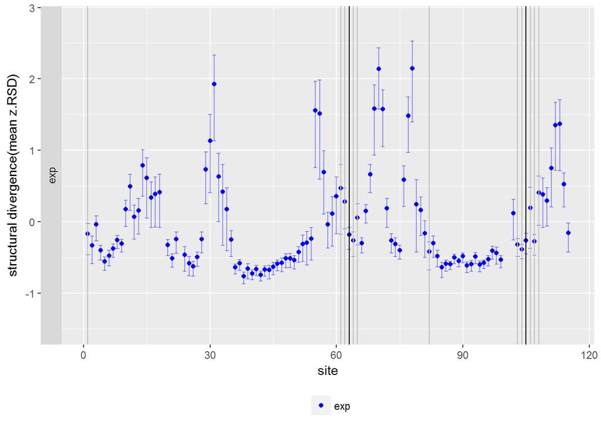

Black lines are the active sites and grey lines are their contacts

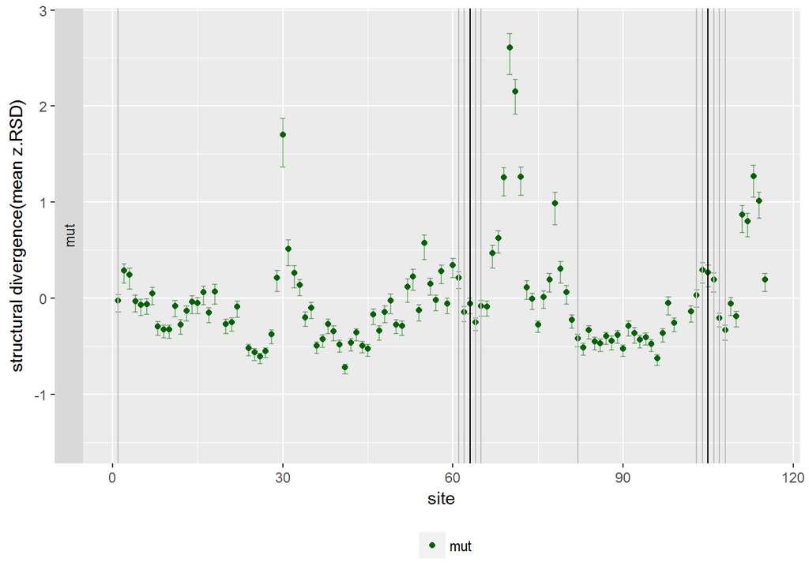

Black lines are the active sites and grey lines are their contacts

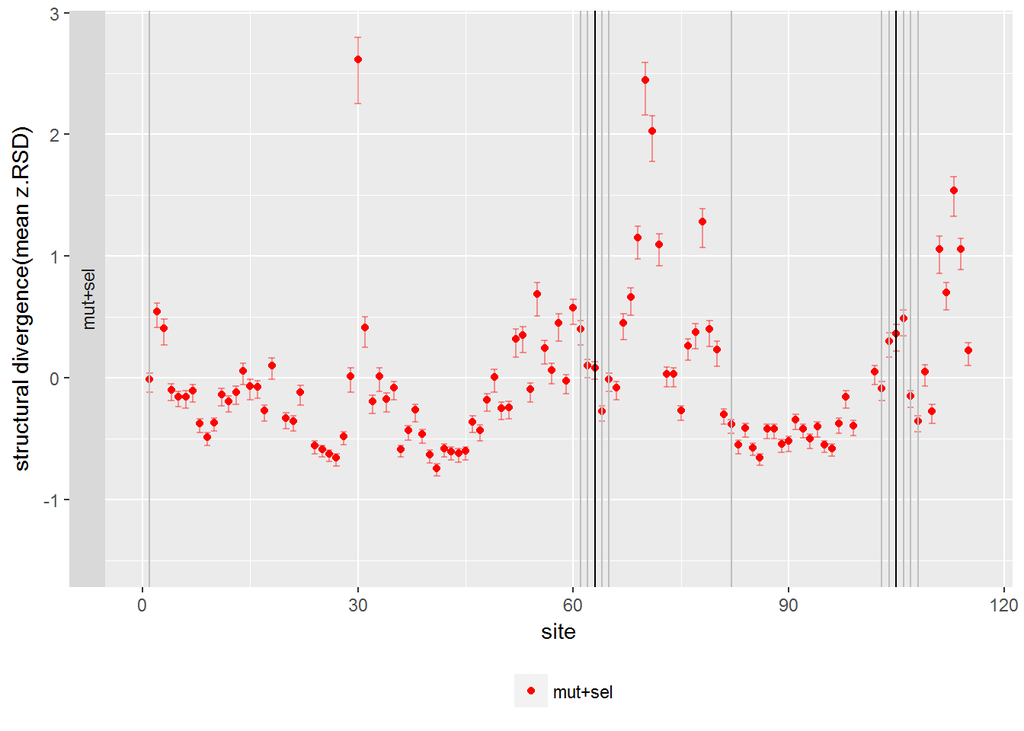

Black lines are the active sites and grey lines are their contacts

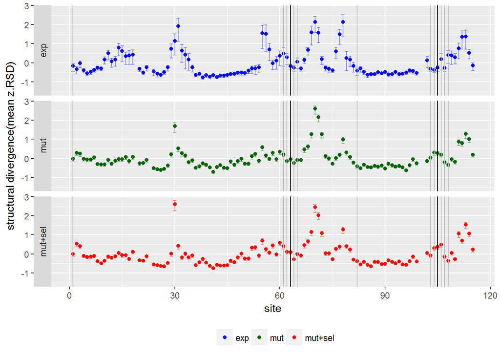

Black lines are the active sites and grey lines are their contacts

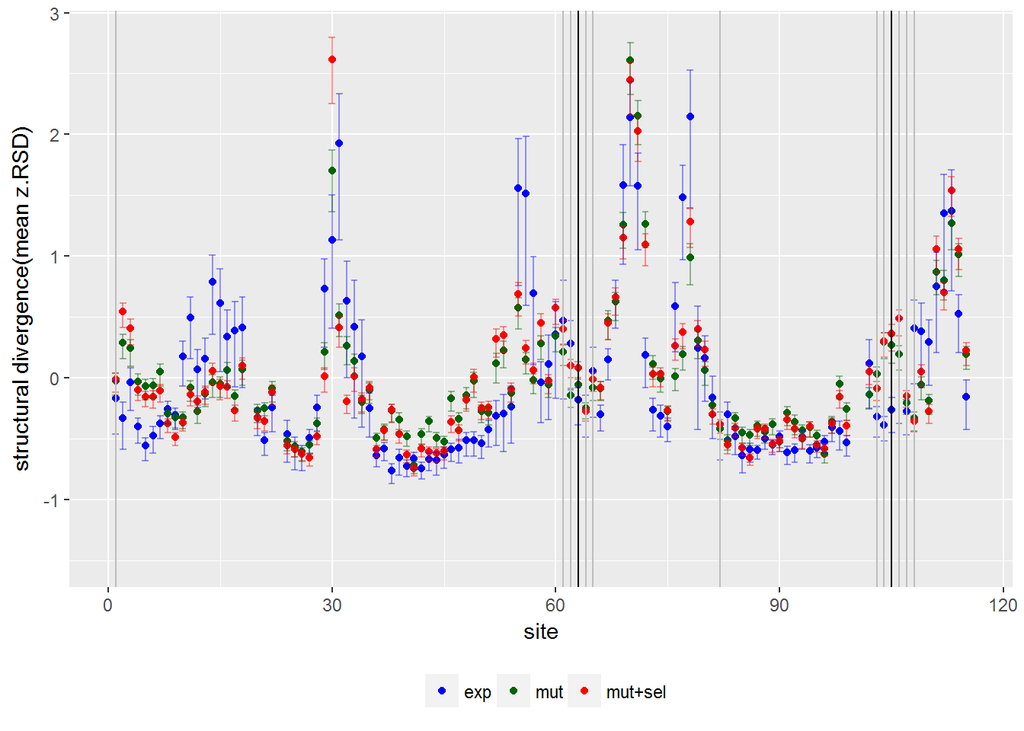

Black lines are the active sites and grey lines are their contacts

### Correlation between site profiles

Correlation between profiles

| comparison | R |
| --- | --- |
| exp vs mut | 0.77 |
| exp vs strong | 0.76 |
| mut vs strong | 0.97 |

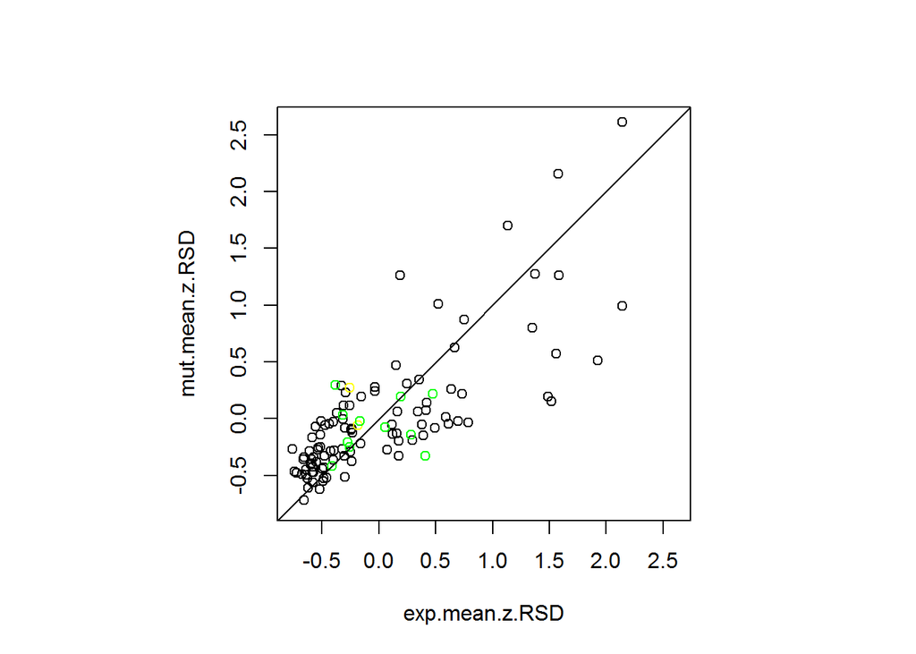

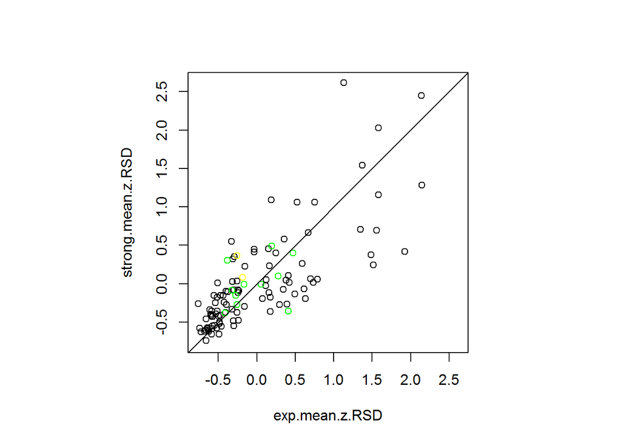

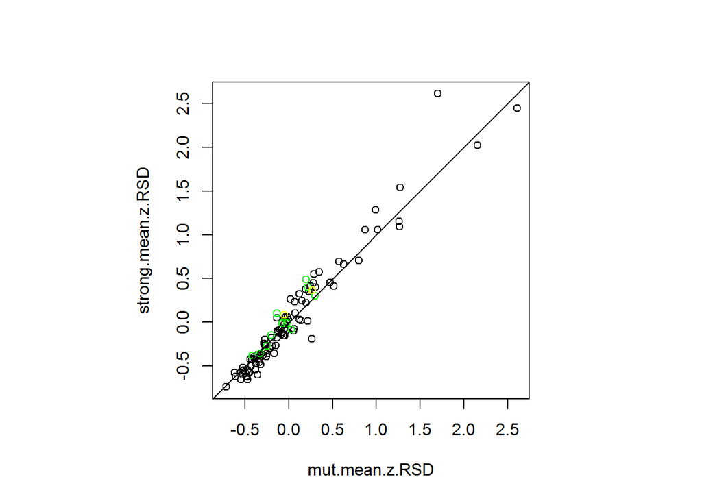

### Distance to the active site

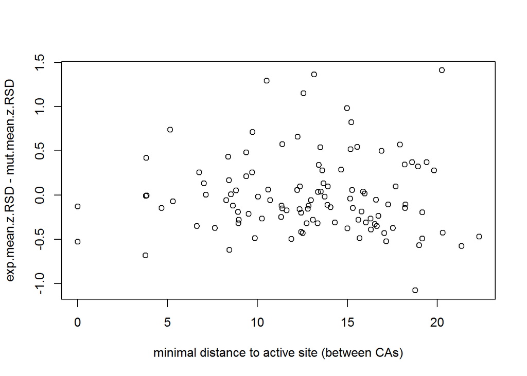

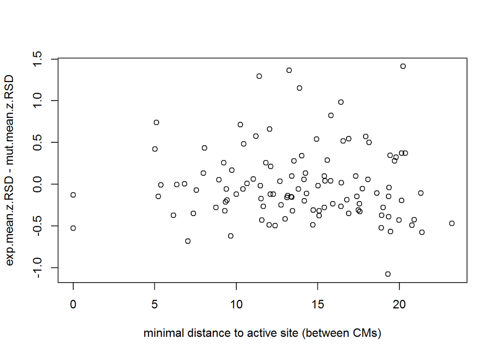

Correlation between differences in profiles and the minimal distance to the active site

| comparison | R |
| --- | --- |
| (exp - mut) vs min.da.CA | -0.02 |
| (exp - mut) vs min.da.CM | -0.03 |

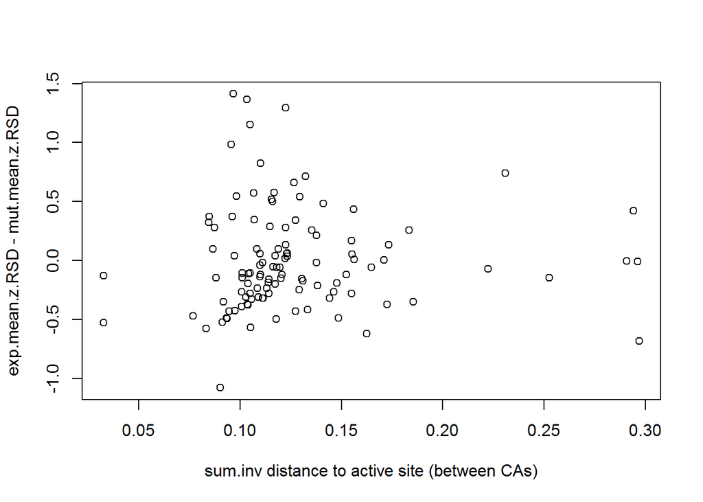

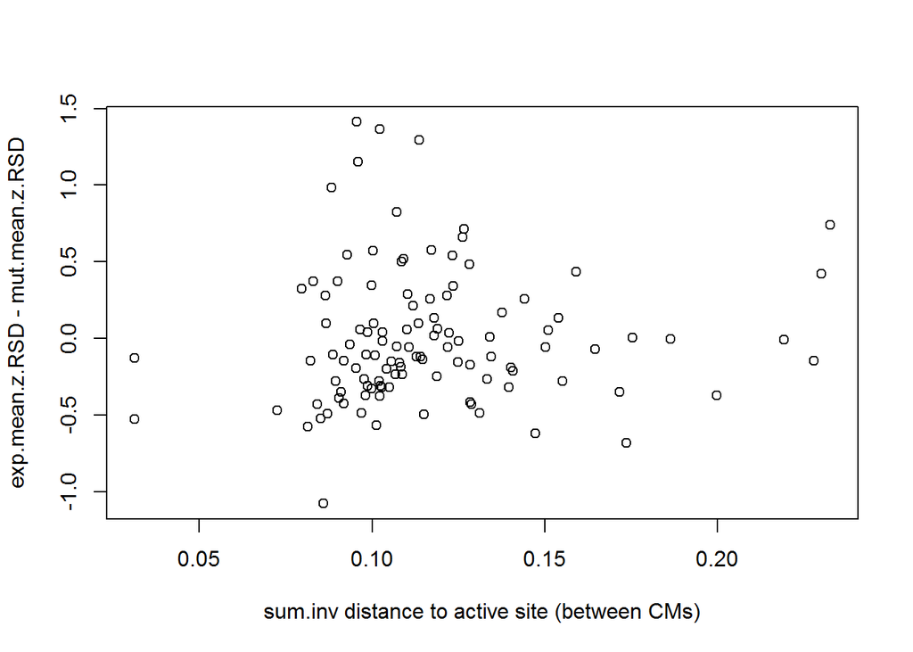

Correlation between differences in profiles and the sum.inv distance to the active site

| comparison | R |
| --- | --- |
| (exp - mut) vs sum.inv.da.CA | 0.03 |
| (exp - mut) vs sum.inv.da.CM | 0.07 |

Correlation between CN and the minimal distance to the active site

| comparison | R |
| --- | --- |
| CN vs min.da.CA | 0.01 |
| CN vs min.da.CM | 0.04 |

Correlation between CN and the sum.inv distance to the active site

| comparison | R |
| --- | --- |
| CN vs sum.inv.da.CA | 0.09 |
| CN vs sum.inv.da.CM | 0.14 |

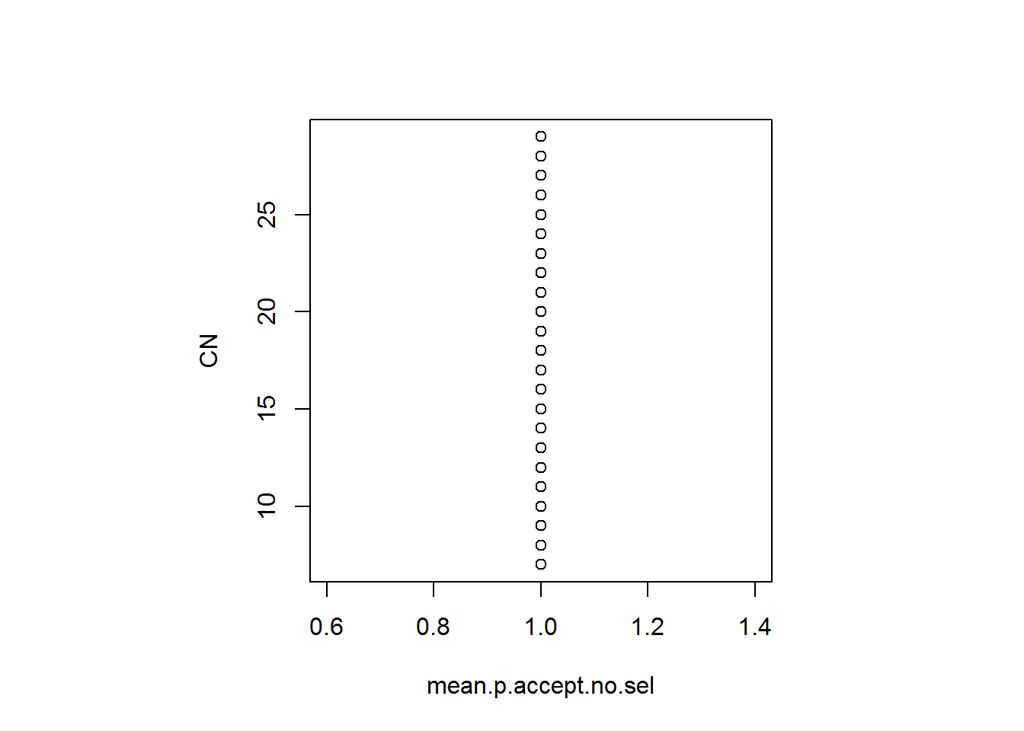

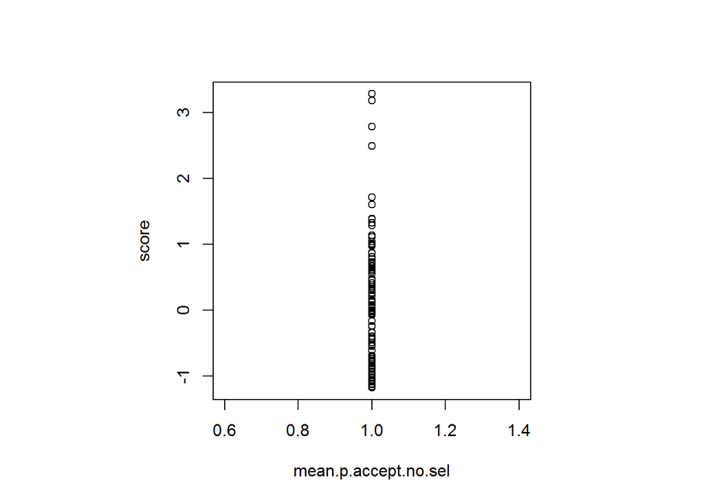

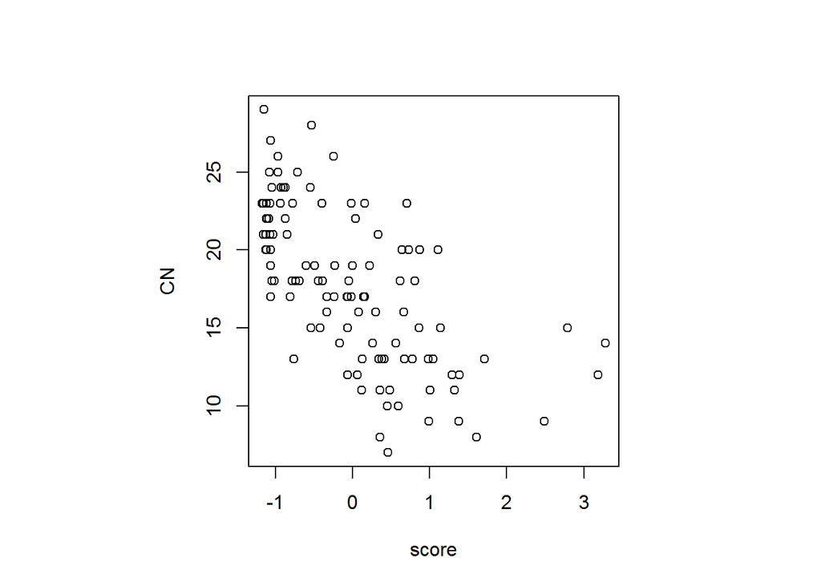

Correlation between sequence profiles

| comparison | R |
| --- | --- |
| p.accept.no.sel vs CN | NA |
| p.accept.no.sel vs score | NA |
| score vs CN | -0.65 |

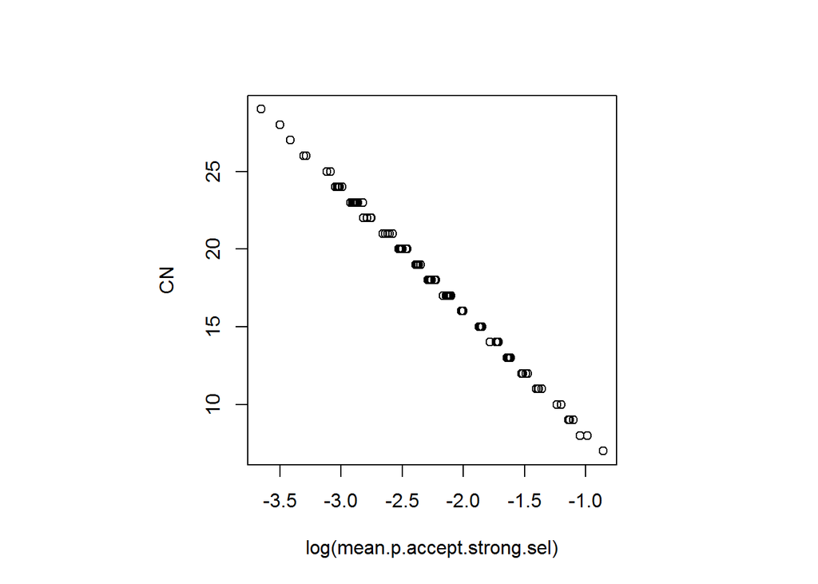

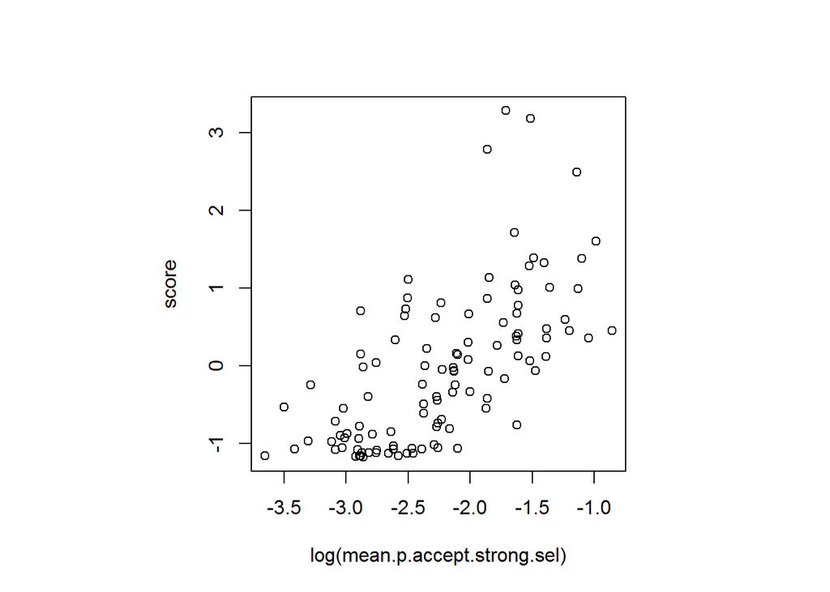

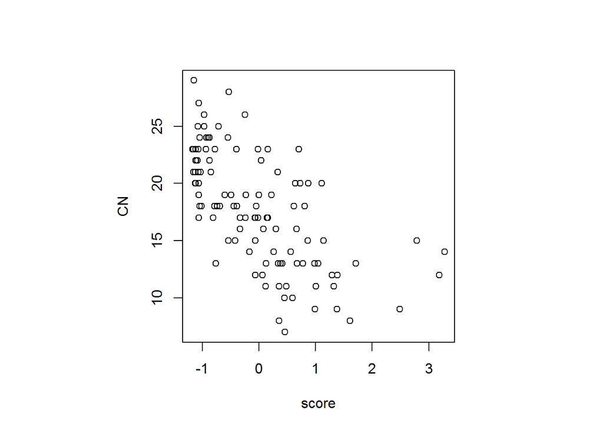

Correlation between sequence profiles

| comparison | R |
| --- | --- |
| log(p.accept.strong.sel) vs CN | -1.00 |
| log(p.accept.strong.sel) vs score | 0.66 |
| score vs CN | -0.65 |